# Challenge 1: figures for publication

Solene Derville - solene.derville@oregonstate.edu

Feb 28, 2023

### Load R libraries

```r
library(tidyverse)
library(ggpubr)
library(patchwork)
library(raster)
library(ggridges)
library(ggthemes)
```

### Load dataset

Extracted from GBIF: GBIF.org (09 May 2021) GBIF Occurrence Download https://doi.org/10.15468/dl.frb56w This file contains all GBIF occurrences of the Felidae family collected in Oregon (approximated by a box of longitude [-128.6, -119.3] and latitude [41.1, 46.2]), from 1900 to present (filtering out occurrences with uncertain coordinates)

```r
# import the csv in R into a dataframe. The .csv file needs to be in your working directory for this to work
# to change working directory, click on > Session > Set Working Directory > Choose Working Directory
dfel <- read.csv("dataset1_GBIF_observations.csv", sep = ";")

# this dataset has many columns, some of which are not necessary here so let's simplify the dataframe by selecting specific columns
dfel <- dfel %>%
  dplyr::select(gbifID, family, genus, species, individualCount, decimalLatitude, decimalLongitude, eventDate, month, year, institutionCode)
```

Extracting the elevation at the position where Felidae species were observed

```r
# elevation downloaded from GEBCO
# this object is in raster format
r <- raster("dataset2_gebco_map.tif")

# extract elevation and add it as a column in your dataframe d
dfel$elev <- raster::extract(r, dfel[c("decimalLongitude", "decimalLatitude")])

# for the purpose of these exercises, let's simply remove the observations for which elevation was not extracted
# there are couple observations with elev < 0 that don't make sense, let's set this to 0
dfel <- dfel %>%
  filter(!is.na(elev)) %>%
  mutate(elev = ifelse(elev < 0, 0, elev))
```

## Challenge objective: Compare the elevation and geographical distribution (latitude and longitude) of Felidae species occurrences.

### Path to a ready-to-publish figure

1. Since several response variables must be compared, you might need to assemble several plots with the package `patchwork`. Label panels (a, b, c etc.) with `plot_annotation`
2. Compare the response variables with the chart type of your choice, using for instance: `geom_boxplot`, `ggridges::geom_density_ridges`, `geom_violin` etc.
3. Run statistical tests to compare species and add results to the plots with `ggpubr::stat_compare_means`
4. Save the figure at 600 dpi, in tiff format and 2-column dimensions with `ggsave`
5. Write the caption that would go with the figure if it was published in a peer-reviewed journal

### A few tips

- Including p-values and statistical test results in a plot: http://www.sthda.com/english/articles/24-ggpubr-publication-ready-plots/76-add-p-values-and-significance-levels-to-ggplots/
- Some ideas if you want to add color: https://www.canva.com/learn/100-color-combinations/ or https://github.com/EmilHvitfeldt/r-color-palettes
- Tips for using patchork: https://www.datanovia.com/en/blog/ggplot-multiple-plots-made-ridiculuous-simple-using-patchwork-r-package/

### Example

```r
# set my personal theme
mytheme <- theme(panel.border = element_rect(linewidth=0.5,color="black", fill="transparent"), #white background
        panel.background = element_rect(fill = 'white'),
        text=element_text(face="bold", size=8), #general size for all text.looks small here but ok once using ggsave with 600 dpi and default pointsize
        title = element_text(size=rel(1.2))) # all titles will be a little larger than labels

# set levels of comparison for kruskal wallis test
my_comparisons <- list( c("Felis catus", "Lynx rufus"), c("Lynx rufus", "Puma concolor"), c("Felis catus", "Puma concolor"))

g1 <- ggplot(dfel, aes(x = species, y = elev, fill = species, col = species)) +
  geom_boxplot(alpha = 0.8) +
  stat_compare_means(comparisons = my_comparisons,
                     label.y = c(2000, 2800, 3500),
                     label = "p.signif",
                     p.adjust.method = "none") + # Add pairwise comparisons p-value
  stat_compare_means(label.y = 4500) +   # Add global p-value
  scale_y_continuous("Elevation (m)", limits = c(0, 5000)) +
  scale_x_discrete("Felidae Species")
```

[output not shown]

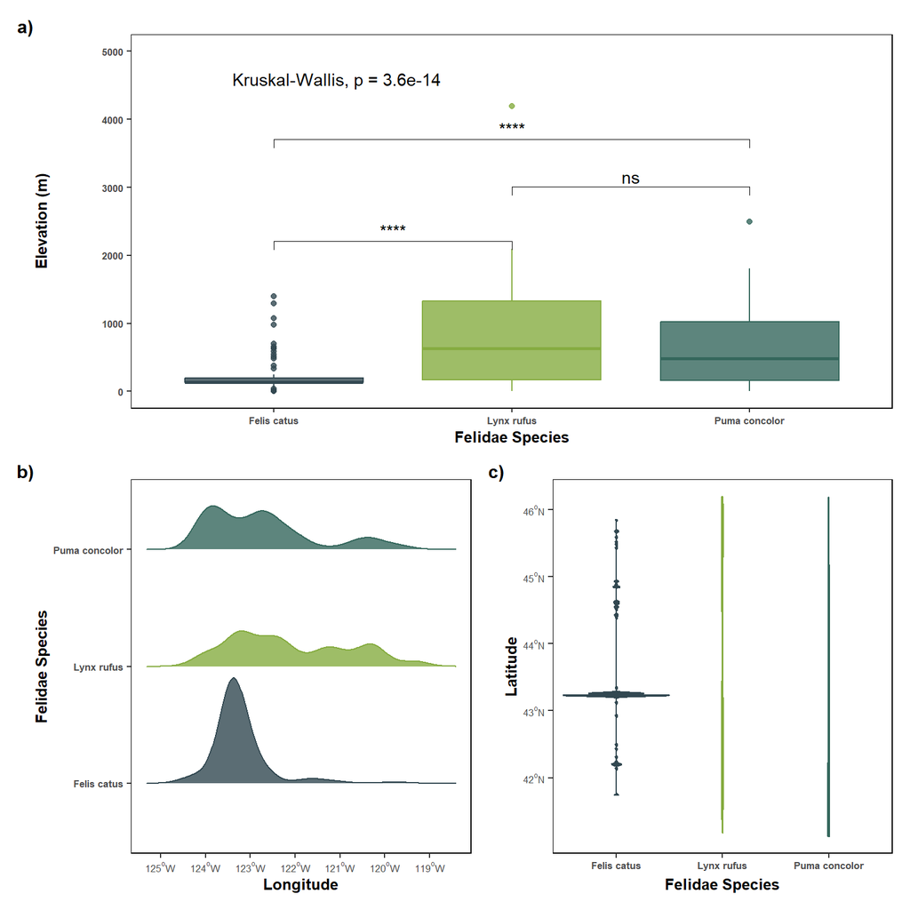

```r
g2 <- ggplot(dfel, aes(x = decimalLongitude, y = species)) +
  # density_ridges are an alternative to boxplots
  geom_density_ridges(aes(fill = species, col = species), alpha = 0.8, scale = 0.9) +
  scale_y_discrete("Felidae Species") +
  # use parse to make the lat and long labels look good
  scale_x_continuous("Longitude", breaks = seq(-125, -119, 1),
                   labels = parse(text=paste0(seq(125, 119, -1),"^o", "*W")))

g3 <- ggplot(dfel, aes(x = species, y = decimalLatitude)) +
  # violin plots are another alternative to boxplots
  geom_violin(aes(fill = species, col = species), width = 1) +
  scale_y_continuous("Latitude", breaks = seq(42, 46, 1),
                   labels = parse(text=paste0(seq(42, 46, 1),"^o", "*N"))) +
  scale_x_discrete("Felidae Species")

g <- (g1 / (g2 + g3)) &
  # add the same color scale everywhere
  scale_color_canva(guide = "none", palette = "Playful greens and blues") &
  scale_fill_canva(guide = "none", palette = "Playful greens and blues") &
  # number panels: a), b), c)
  plot_annotation(tag_levels = "a", tag_suffix = ")") &
  # add theme to all panels at the same time
  mytheme
g
```

```r
# save in a high resolution tiff, full page width format
ggsave(g, file = "Challenge1_figure_for_publication.tiff", width = 88*2, height = 88*2, dpi = 600, units = "mm")
```